# Data_story_report

After removing all columns except class-number and each protein tested, a repeated measures ANOVA was performed to examine whether the protein levels between classes 1-8 are significantly different. The results were also plotted as a box plot for each protein. From the plots, some *potential* general trends were observed:

- Little to no difference between classes

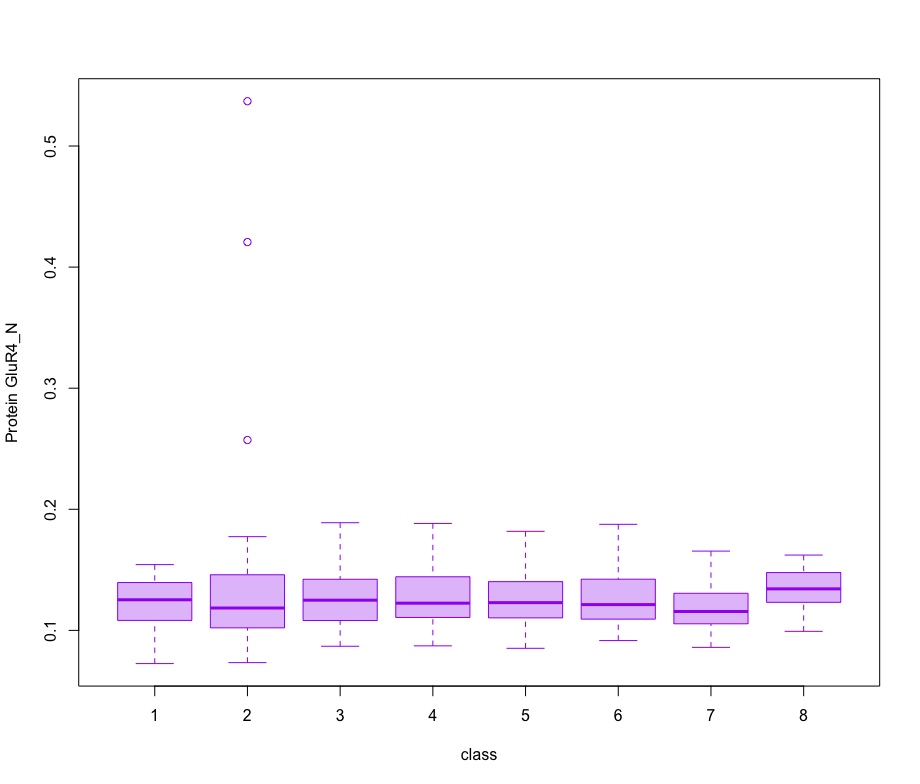

  Figure 2. Little to no difference between classes

- Differences between genotype

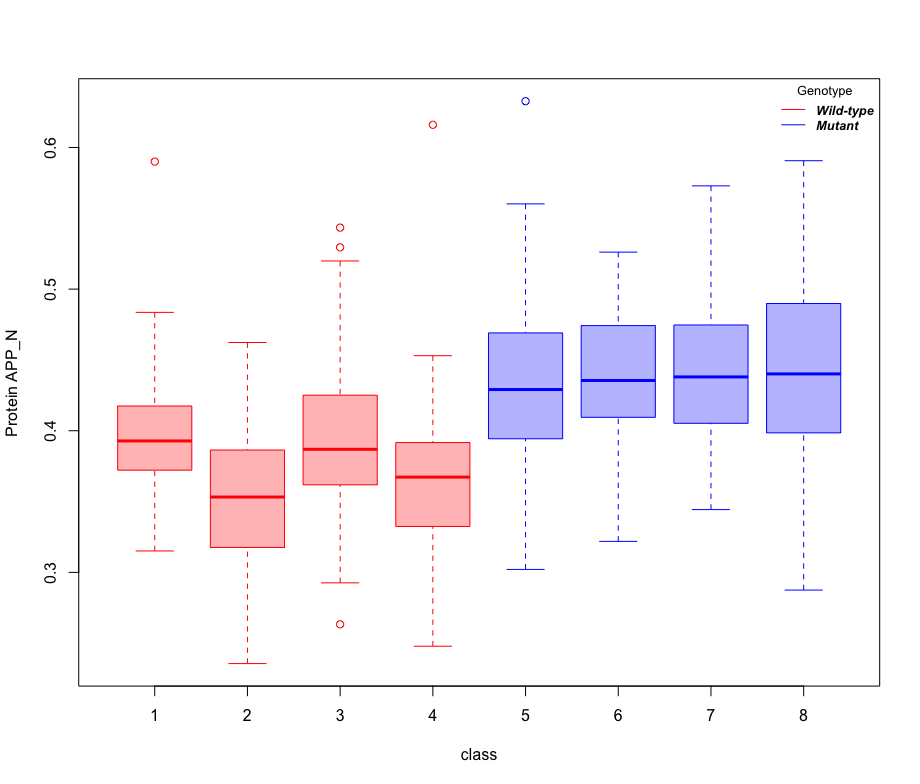

  Figure 3. Differences between genotypes

- Differences between behavior test given

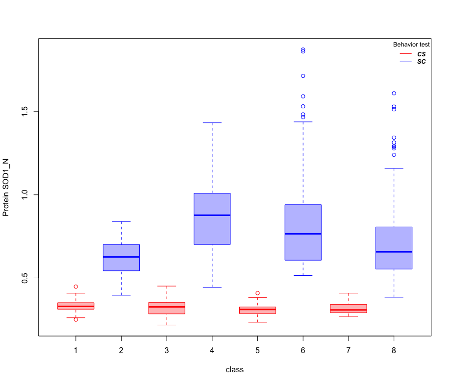

  Figure 4. Differences between behavior test given

- Differences between drug given and not given

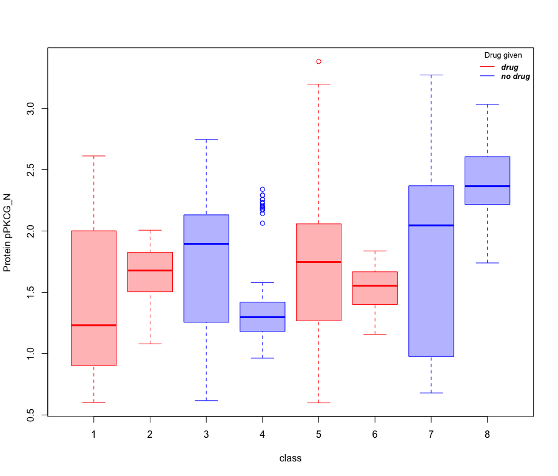

  Figure 5. Differences between drug and no drug. For example, Class 6 and Class 8 differ only by whether or not the drug was provided.

## Future Directions

Given the findings above, a model will be created that will investigate the relationship between the expression levels of a particular protein and each class of mice examined. A logistic regression method will be used to fit a regression curve for the categorical variable class/class_number. The optimal goodness-of-fit will be determined after combinatorial modeling is performed, where all combinations of proteins will be examined for each class number. From this, the goal is to be able to differentiate whether a mouse is within a particular class based on protein expression levels measured.

In addition, potential therapeutic targets will be proposed. The output from the data wrangling and statistical analyses will be used to explore and identify sets of proteins that vary under the different experimental conditions. The classes that will be focused on are Class 5 and Class 7. Both of these classes are the Ts65Dn mice that were given the learning behavioral test; however, Class 5 was given the drug memantine, while Class 7 was given the control saline. Because of this difference in drug exposure, Class 5 displays more learning than Class 7. Thus, it would be interesting to see if there are any differences in protein expression between these 2 classes. This may suggest a potential therapeutic target or target pathway for aiding in learning and memory for those affected by Down Syndrome.